# Don’t use multimodel averaging to understand multifactorial systems

3 July 2018

## acknowledgements

money: NSERC

ideas: Jonathan Dushoff, Marm Kilpatrick, Brian McGill, Daniel Park, Daniel Turek

## what are multifactorial systems?

- many processes contribute to pattern
- quantify *how* each process affects the system,  
  rather than testing *whether* we can detect its impact
- related:
  - Chamberlin's method of multiple working hypotheses  
    (Raup et al. 1995)
  - tapering effect sizes (Burnham et al. 2002)

This talk is mostly about *inferential* or *scientific* questions  
(but also applies to prediction/management)

## what is multimodel averaging (MMA)? (Burnham et al. 2002)

- typical approach
  - fit full model; dredge; compute AIC weights
  - present table of models with \(\Delta\)AIC & weights
  - compute model-averaged point estimates and CIs
- **many** ways to do it wrong  
  e.g. Cade (2015); Brewer et al. (2016); Galipaud et al. (2014)
  - … but let's not worry about that now

## why use MMA?

- avoid omitting potentially important predictors
- avoid overfitting
- \(\approx\) optimize bias-variance tradeoff
- avoid stepwise approaches & pairwise comparisons
- MMA is a **shrinkage estimator** (Dahlgren 2010)

[figure not shown]

Rackham 1837

## why *not* use MMA?

three problems:

- conceptual
- computational
- inferential

## conceptual problem: discretization

- information-theoretic (IT) approaches often framed as descendants of Chamberlin (Elliott et al. 2007)
- but IT focuses on differentiating **discrete** hypotheses/models
- submodels are always straw men
- ¿ does this actually cause problems ?

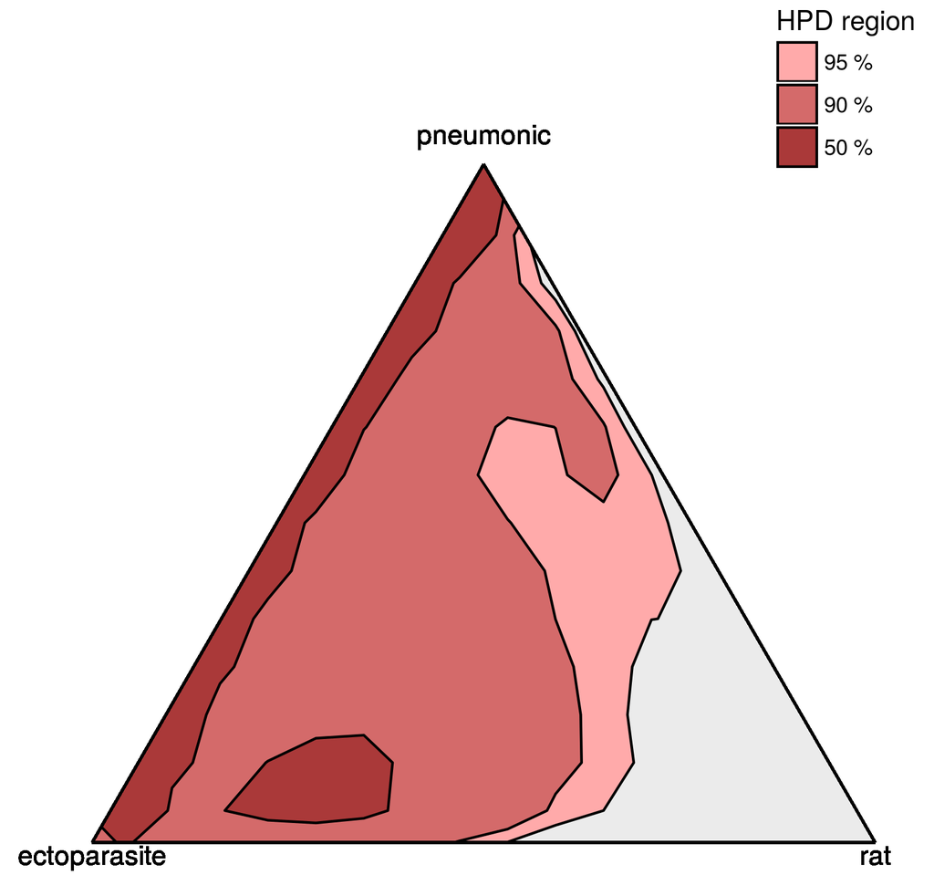

Estimated contribution of plague transmission modes in Eyam 1665

## computational problem: efficiency

- classic MMA requires fitting **lots** of models: \({{\mathcal{O}}}(2^K K^2 n)\)
- more efficient shrinkage estimators:  
  lasso/ridge/etc.; random forest etc.; Bayesian + regularizing priors
- \({{\mathcal{O}}}(K^2 n)\) or \({{\mathcal{O}}}(K n \log(n))\)  
  (Hardy 2017; Louppe 2014)  
  (may need to tune shrinkage)
- we do have lots of computers …

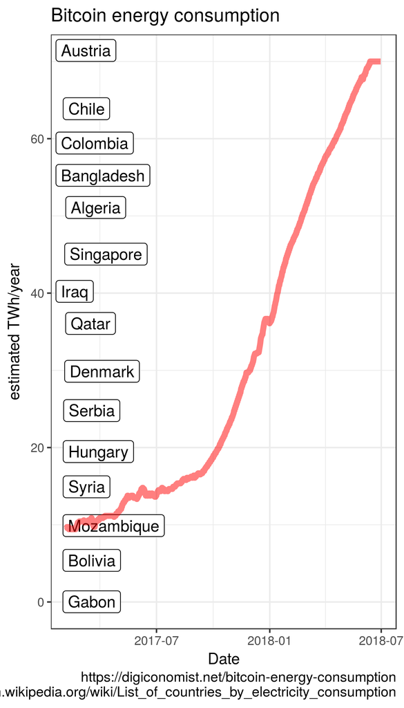

## inferential problem: undercoverage

- various methods for constructing MMA CIs (Burnham et al. 2002; Fletcher et al. 2012; Kabaila et al. 2016)
- MMA CIs are generally **too narrow**  
  (D. B. Turek 2013; Kabaila et al. 2016; Dormann et al. 2018) but cf. Burnham et al. (2002)
- general property of shrinkage estimators? e.g. ridge-regression CI width \(\geq\) least-squares CI (Obenchain 1977)
- **no free lunch**; can we ever gain certainty by shrinkage?

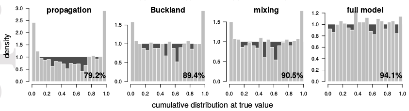

Dormann et al. (2018), Figure 5

## possible reactions

- "MMA CIs only undercover a little bit"
  - then they're not good CIs; increased certainty is an illusion
- "I'm only interested in prediction"
  - really?
  - do you want reliable CIs on your predictions?
- "MMA is the only shrinkage estimator available for my problem"
  - let's work on this

## conclusions: what should you do?

- for **inference**:
  - use the full model
  - *a priori* model reduction (Harrell 2001)
- for **prediction**:
  - beware CIs from shrinkage estimates
  - help develop efficient, principled shrinkage estimation methods
  - use non-neutral, informative Bayesian priors?  
    (Crome et al. 1996)

http://github.com/bbolker/discretization

[figure not shown]

https://imgflip.com

## References

Brewer, MJ et al. 2016. *Methods in Ecology and Evolution* 7 (6): 679–692. doi:10.1111/2041-210X.12541. http://onlinelibrary.wiley.com/doi/10.1111/2041-210X.12541/abstract.

Burnham, KP et al. 2002. *Model Selection and Multimodel Inference: A Practical Information-theoretic Approach*. Springer.

Cade, BS. 2015. *Ecology*. doi:10.1890/14-1639.1. http://www.esajournals.org/doi/abs/10.1890/14-1639.1.

Crome, FHJ et al. 1996. *Ecological Applications* 6: 1104–1123.

Dahlgren, JP. 2010. *Ecology Letters* 13 (5): E7–E9. doi:10.1111/j.1461-0248.2010.01460.x. http://onlinelibrary.wiley.com/doi/10.1111/j.1461-0248.2010.01460.x/abstract.

Dormann, CF et al. 2018. *Ecological Monographs*. doi:10.1002/ecm.1309. https://esajournals.onlinelibrary.wiley.com/doi/abs/10.1002/ecm.1309.

Elliott, LP et al. 2007. *BioScience* 57 (7): 608–614. doi:10.1641/B570708. https://academic.oup.com/bioscience/article/57/7/608/238555.

Fletcher, D et al. 2012. *Journal of agricultural, biological, and environmental statistics* 17 (1): 38–51.

Galipaud, M et al. 2014. *Methods in Ecology and Evolution* 5 (10): 983–991. doi:10.1111/2041-210X.12251. http://onlinelibrary.wiley.com/doi/10.1111/2041-210X.12251/abstract.

Hardy, R. 2017. *Cross Validated*. https://stats.stackexchange.com/questions/177665/speed-computational-expenses-of-pca-lasso-elastic-net.

Harrell, F. 2001. *Regression Modeling Strategies*. Springer.

Kabaila, P et al. 2016. *Scandinavian Journal of Statistics* 43 (1): 35–48. doi:10.1111/sjos.12163. http://onlinelibrary.wiley.com/doi/10.1111/sjos.12163/abstract.

Louppe, G. 2014. PhD Thesis, Faculty of Applied Sciences, Department of Electrical Engineering & Computer Science: University of Liège. https://arxiv.org/pdf/1407.7502.

Obenchain, R. 1977. *Technometrics* 19 (4): 429–439.

Raup, DC et al. 1995. *The Journal of Geology* 103 (3): 349–354. http://www.jstor.org/stable/30071227.

Turek, DB. 2013. PhD thesis, University of Otago. https://www.otago.ourarchive.ac.nz/bitstream/handle/10523/3923/TurekDanielB2013PhD.pdf.